# CSEd SE network analysis

Moudgalya & Staudt Willet

11/12/2018

# Introduction

The Stack Exchange Network is one of the largest question-and-answer platforms in the world, founded in 2009 and boasting over 100 million unique monthly visitors by 2015. It has many subject-specific forums for coding related topics, Mathematics, Engineering, Photography, etc.—133 different sites as of October 2018. More recently, Stack Exchange has recently opened up discussion forums for Math educators (2013) and Computer Science educators (2016) as well. For this project, we will focus on the users of the discussion forum Computer Science Educators’ StackExchange (CSEd SE) (https://cseducators.stackexchange.com/). The description of the forum calls it ‘A question and answer site for those involved in the field of teaching Computer Science.’

In this forum, registered users can ask questions on a wide range of topics related to Computer Science (CS) education. Once they ask a question, they can assign it ‘tags’, so that similar groups of questions can be identified by a common theme or idea. Some tags that are currently present on the forum include ‘curriculum design,’ ‘student motivation,’ ‘algorithm,’ etc. Users can also reply to (i.e., answer) questions posed by other users, comment on both questions and answers, upvote and downvote questions and answers, and so on—through the voting mechanism, users are held accountable to what they post on the forum. The content on the forum is thus regulated by the forum users and members to a large extent.

In addition to ‘normal’ user regulation, a set of registered users also act as ‘moderators’ or ‘editors’. Editors can edit the text of what other people post. Moderators, on the other hand, have more power. They can follow up with posts that are flagged as spam or offensive, delete and manage other users, combine or collapse tags, lock posts so that no one can change them or vote on them, and so on.

The users on this forum range from actual K-12 and college-level CS educators to working professionals in the software industry, students, and other people interested in CS education. The users also belong to many different countries, such as the USA, UK, Canada, Ireland, India, Finland, etc. Each user has ‘reputation’ points primarily based on the quality of their posts, such as user-generated votes their posts receive. The reputation changes across time are accessible for people to see.

# Purpose

This study explores the kinds of interaction between the users, with a focus on the top voted questions. It seeks to describe the kind of users, based on their profession, location, reputation, etc., that tend to ask questions or respond to the top questions. It also seeks to understand if the users tend to cluster around certain question tags (topic area) or if the clusters are agnostic to the topics and user characteristics.

In the second part of the study, we will focus on trying to interpret the reasons for users choosing to answer the questions. It will explore if the reasons are dependent to the topic tag or some characteristic of the users who ask the question.

# Theoretical Framework and Research Questions

Communities of practice are “….groups of people who share a concern or a passion for something they do and learn how to do it better as they interact regularly” (Wenger, 2011, p. 1). These communities have the following traits: (a) a domain of shared interest; (b) people who engage in joint activities and discussions; and (c) members who are practitioners (such as educators). Further, according to Wenger, they should demonstrate (a) mutual engagement (such as a dialogue instead of one directional information flow); (b) a joint enterprise; and (c) a shared repertoire. These three traits represent “…three dimensions of the relation by which practice is the source of coherence of a community” (Wenger, 1998, p. 72).

The CSEd SE has many elements that could potentially make it a ‘community of practice’. For instance, there are clear boundaries in terms of membership to the forum. The forum has a unique purpose, that is to build knowledge and dialogue in the domain of CS education. Further, the discussions on the forum are not generally a unidirectional venture. The commenting feature, for instance, allows scope for a back and forth dialogue. Finally, the presence of moderators and editors for maintenance of the forum, scope of democratic elections for the selection of moderators, reputation points based on user-generated voting system, gives CSEd SE the traits of a community of practice. Indeed, a literature review of informal online teacher communities revealed that the communities of practice framework has often been used to study teacher interactions in online forums (Macià & García, 2016).

# Method

## Data Analysis

```r
## merging the answers to the top 50 questions
csed <- csed_ques_top %>% inner_join(csed_og[[1]], by = "question_id") %>%
        as.data.frame

#csed$question_id %>% unique %>% length   # these are the number of different questions

csed$askers <- csed$owner_display_name.x %>% as.character
csed$responders <- csed$owner_display_name.y %>% as.character

#csed$askers %>% unique %>% length  # these are the different question askers
#csed$responders %>% as.character %>% unique %>% length  # these are the different responders

#csed %>% group_by(owner_display_name.y) %>% summarize(view_count %>% mean)


## --------------------------------------------------------------
## posts per contributor
## --------------------------------------------------------------

responders <- csed$responders %>% table %>% as.data.frame %>% arrange(desc(Freq))


## --------------------------------------------------------------
## calculating descriptive statistics
## --------------------------------------------------------------

library(moments)
responders$Freq %>% mean %>% round(2)
```

```
## [1] 1.86
```

```r
responders$Freq %>% sd %>% round(2)
```

```
## [1] 3.33
```

```r
responders$Freq %>% median %>% round(2)
```

```
## [1] 1
```

```r
responders$Freq %>% min
```

```
## [1] 1
```

```r
responders$Freq %>% max
```

```
## [1] 39
```

```r
responders$Freq %>% skewness %>% round(2)
```

```
## [1] 7.97
```

```r
responders$Freq %>% kurtosis %>% round(2)
```

```
## [1] 79.41
```

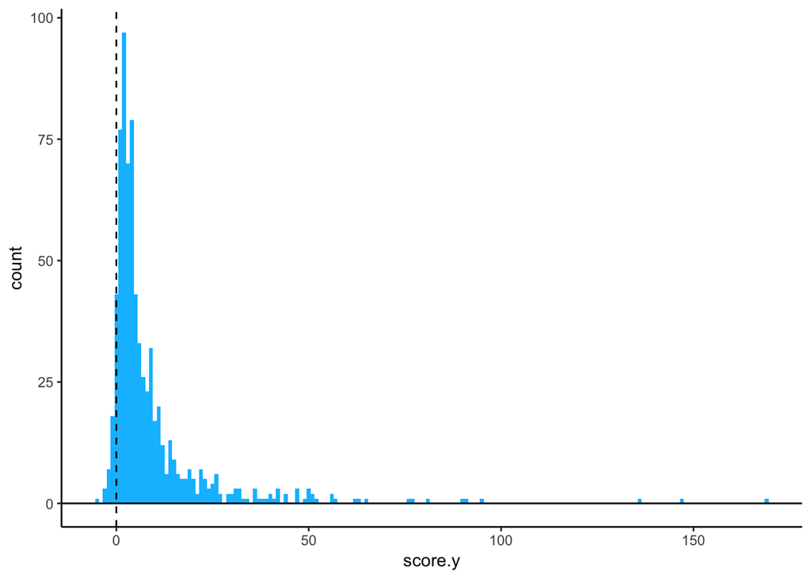

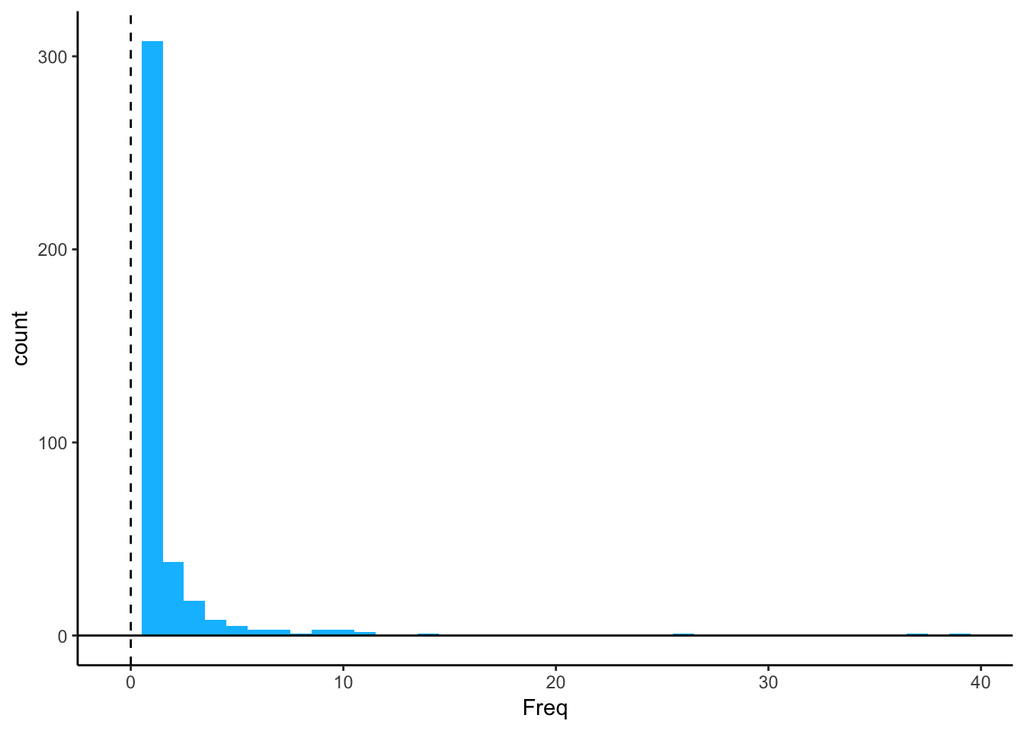

### Create the Network Graph

```r
library(tidyverse); library(igraph)
csed_graph <- csed %>% dplyr::select(responders, askers) %>%
        as.matrix %>% graph_from_edgelist(directed=TRUE)
# csed_graph %>% summary
```

### Network Statistics

```r
csed_graph %>% gsize  # number of edges
```

```
## [1] 737
```

```r
csed_graph %>% V %>% length  # number of vertices/nodes
```

```
## [1] 416
```

```r
csed_graph %>% edge_density  # the ratio of the number of edges and the number of possible edges.
```

```
## [1] 0.004268999
```

```r
        # Also called cohesion.
csed_graph %>% transitivity("global")  # the probability that the adjacent vertices of a vertex are connected.
```

```
## [1] 0.05006284
```

```r
        # Also called the clustering coefficient. The balance of connections.
csed_graph %>% vertex_connectivity  # If the graph is not (strongly) connected then the connectivity is obviously zero.
```

```
## [1] 0
```

```r
csed_graph %>% diameter  # the length of the longest geodesic (max distance between two vertices)
```

```
## [1] 5
```

```r
csed_graph %>% reciprocity  # defines the proportion of mutual connections, in a directed graph.
```

```
## [1] 0.03867403
```

```r
        # most commonly defined as the probability that the opposite counterpart of a directed edge is also included in the graph.
csed_graph %>% eigen_centrality %>% '$'(value)  # The eigenvalue corresponding to the calculated eigenvector, i.e. the centrality scores.
```

```
## [1] 25.81937
```

```r
        # Eigenvector centrality scores correspond to the values of the first eigenvector of the graph adjacency matrix;
        # these scores may, in turn, be interpreted as arising from a reciprocal process in which the centrality of each actor is proportional to the sum of the centralities of those actors to whom he or she is connected.
        # vertices with high eigenvector centralities are those which are connected to many other vertices which are, in turn, connected to many others (and so on).
csed_graph %>% authority_score %>% '$'(value)  # The corresponding eigenvalue of the calculated principal eigenvector.
```

```
## [1] 316.4608
```

```r
        # The authority scores of the vertices are defined as the principal eigenvector of AT A, where A is the adjacency matrix of the graph.
csed_graph %>% hub_score %>% '$'(value)  # The corresponding eigenvalue of the calculated principal eigenvector.
```

```
## [1] 316.4608
```

```r
csed_graph %>% centr_clo_tmax  # Theoretical maximum for closeness centralization
```

```
## [1] 414.0024
```

### Clustering

A community is a set of nodes with many edges inside the community and few edges between outside it (i.e. between the community itself and the rest of the graph).

The *spinglass clustering* algorithm maps community detection onto finding the ground state of an infinite range spin glass. Csárdi, Nepusz, and Airoldi (2016, pp. 132-133) explained:

“The clustering method of [Reichardt and Bornholdt](https://arxiv.org/abs/cond-mat/0603718) (2006) is motivated by spin glass models from statistical physics. Such models are used to describe and explain magnetism at the microscopic scale at finite temperatures. Reichardt and Bornholdt (2006) drew an analogy between spin glass models and the problem of community detection on graphs and proposed an algorithm based on the simulated annealing of the spin glass model to obtain well-defined communities in a graph. A spin glass model consists of a set of particles called spins that are coupled by ferromagnetic or antiferromagnetic bonds. Each spin can be in one of k possible states. The well-known Potts model then defines the total energy of the spin glass with a given spin configuration… Spins and interactions in the Potts model are very similar to graphs: each spin in the model corresponds to a vertex, and each interaction corresponds to an edge… Reichardt and Bornholdt (2006) gave efficient update rules for the above energy function, making it possible to apply a simulated annealing procedure to find the ground state of the model that corresponds to a low energy con- figuration. Their algorithm starts from a random configuration of spins and tries to flip all the spins once in each time step. After each individual spin flip, the energy of the new configuration is evaluated.”

In other words, the spinglass clustering algorithm partitions the vertices into communities by optimizing an energy function. The initial R code to produce spinglass clusters is straightforward:

```r
csg <- csed_graph %>% cluster_spinglass  # creates the clusters
csg$membership %>% unique %>% length  # this is the number of clusters/communities/groups
```

```
## [1] 14
```

One of the important outcomes of this method is the *modularity* value. Modularity measures how good the division is, or how separated are the different vertex types from each other. The spinglass algorithm looks for the modularity of the optimal partition. For a given network, the partition with maximum modularity corresponds to the optimal community structure.

Note that if M = 0, all nodes belong to one group; if M < 0, each node belongs to separate community.

```r
csg$modularity  # The modularity of a graph with respect to some division (or vertex types)
```

```
## [1] 0.5214896
```

*Test of Statistical Significance*

The test for statistical significance for spinglass clustering is a bit different than the familiar tests that return *p*-values (Csárdi, Nepusz, & Airoldi (2016, pp. 132-138).

The idea behind this test of siginficance is that a random network of equal size and degree distribution as our observed network should have a lower modularity score—that is, if the observerd network does in fact have statistically significant clustering.

The following R procedure generates 100 randomized instances of our network (with the same size and degree distribution) using the `sample_ degseq()` function. The `method = 'vl'` ensures that there are no loop edges in the randomly generated networks.

A ‘0’ result from this procudure indicates that no randomized networks have community structure with a modularity score that is higher than the one obtained from the original, observed network. Hence a ‘0’ result means that our network has significant community structure.

```r
degrees <- igraph::degree(csed_graph)
q <- csg$modularity
q_rand <- replicate(100, sample_degseq(degrees, method = 'vl'),
                simplify = FALSE) %>%
        lapply(cluster_spinglass) %>%
        sapply(modularity)
sum(q_rand > q) / 100
```

```
## [1] 0
```

*Identifying the “Typical” Number of Clusters Returned with the Spinglass Algorithm*

It is important to note that a different result is returned each time the spinglass clustering algorithm is run. For this reason, we need to run a number of simulations to see what the “typical” number of clusters are. For now, we run the algorithm 100 times and then look at the mean and median number of clusters obtained; for publication, we would run the algorithm 1,000 times.

We make a note of a `seed` reproduces the median number of clusters, confirm that this is reproducible, and then set this seed so that all future work will be run with this same clustering configuration.

```r
csg_matrix <- matrix(NA, nrow=1, ncol=100)
for (i in 1:100) {
        set.seed(i)
        csg <- csed_graph %>% cluster_spinglass
        csg_matrix[1,i] <- max(csg$membership)
}

csg_matrix %>% as.vector %>% mean  # 15.26
```

```
## [1] 15.26
```

```r
csg_matrix %>% as.vector %>% sd  # 1.22
```

```
## [1] 1.219538
```

```r
csg_matrix %>% as.vector %>% min  # 12
```

```
## [1] 12
```

```r
csg_matrix %>% as.vector %>% max  # 18
```

```
## [1] 18
```

```r
csg_matrix %>% as.vector %>% median  # 15
```

```
## [1] 15
```

```r
csg_matrix %>% as.vector %>% skewness
```

```
## [1] -0.03696757
```

```r
csg_matrix %>% as.vector %>% kurtosis
```

```
## [1] 2.678513
```

```r
set.seed(2)  # the solutions look different with a different seed
csg <- csed_graph %>% cluster_spinglass
csg$membership %>% unique %>% length  # number of clusters
```

```
## [1] 15
```

```r
csg$csize  # size of each cluster
```

```
##  [1] 19 21 27 33 27 18 37 38 21 40  8 13 57 11 46
```

```r
csg$modularity  # modularity
```

```
## [1] 0.5238867
```

```r
csg$temperature  # temperature
```

```
## [1] 0.02376045
```

```r
csg$vcount  # number of vertices (nodes)
```

```
## [1] 416
```

```r
#csg$names  # names of each of the vertices (nodes)
```

```r
my_palette <- c("#004972", "#0072B2", "#56B4E9", "#93CFF1",  # blues
                "#F8F2A9", "#F0E442", "#E69F00", "#D55E00",  # yellows/oranges
                "#8BD2BF", "#009E73", "#007354", "#003A2A",  # greens
                "#ECCEDF", "#CC79A7", "#95597A", "#4B2C3D"  # pinks
                )
node_palette <- my_palette[csg$membership]
```

Finally, we create a visualization of our network structure, using the color palette generated by our spinglass clustering. Here, we used the `layout = 'fr'` algorithm, which is appropriate for large (but still with less than 1,000 nodes), potentially disconnected networks.

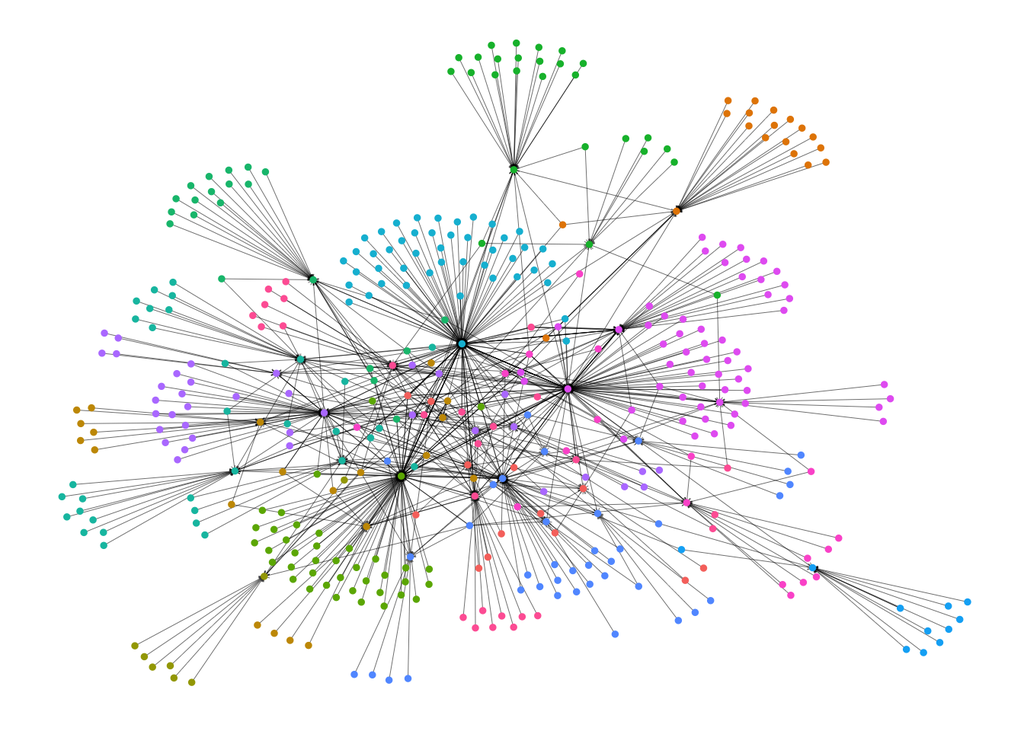

```r
## see https://www.data-imaginist.com/2017/ggraph-introduction-edges/

library(ggraph)
layout <- csed_graph %>% create_layout(layout = 'fr')

ggraph(layout) +
        geom_edge_link(width=.1,
                       arrow = arrow(length=unit(1, 'mm'))
                       ) +
        geom_node_point(alpha=1,
                        size=1,
                        aes(color=node_palette)
                        ) +
        theme_bw() +  # makes background white (not gray)
        theme(plot.background = element_blank(),
              panel.grid.major = element_blank(),
              panel.grid.minor = element_blank(),
              panel.border = element_blank(),
              axis.title = element_blank(),
              axis.text = element_blank(),
              axis.ticks = element_blank(),
              legend.position="none"
        )
```